# *Facial Emotion Detection*

## **Problem definition**

The present challenge is to develop a CNN architecture for extracting emotion from images. In particular, a subset of the FER2013 dataset has been provided. That dataset comprises about 35,000 48x48 monochrome still images labelled into seven emotional categories of which roughly 20,000 in four categories have been retained in the subset.

It should be noted that facial expressions are a *language* which has been evolving for far longer than the human race has existed. To boil this rich language down to a few categories and take it outside of the context of human interaction is to disregard almost everything it contains. All languages are defined by the commonalities between an encoder (a face) and a decoder (some cortices of the brain.) So if a software thinks it can detect facial expressions that a typical human cannot, then by definition it is hallucinating. From this, it readily follows that an artificial facial expression decoder should always be seen as an inferior substitute for the real thing, although it might have practical advantages like scalability, reproducibility and cost.

The following sections will explore the commercial applications of a solution to this problem.

#### **Criteria for evaluating proposed applications**

The scope of this discussion is the set of technological techniques that achieve roughly 75% accuracy (that apparently being the limit of currently known approaches) in deducing emotion from images like those in the provided data set. These images are mainly characterised by being:

- still images rather than videos,
- low quality (monochrome and only 48x48 resolution), and
- taken from a wide variety of angles.

Given a commercial proposal that promises a certain benefit from using such a technique in a certain setting, we might evaluate its financial attractiveness by asking the following questions:

1. What underlying benefit to society or profit margins is hoped for?
2. Is the detection and recording of emotion necessary or sufficient to achieve said benefit?
3. If 2 applies, is the analysis of facial images the best way to detect emotions in the intended setting? Possible alternatives include asking a human and analysing speech sounds or text. Emotion from speech detection reached 87% accuracy by [2016](http://www.apsipa.org/proceedings_2016/HTML/paper2016/137.pdf) and 93.7% by 2023.
4. If 3 applies, is this dataset sufficiently representative of the conditions expected in the usage setting to suggest that success on this dataset leads us to expect technical success in the application?
5. Would a 75% accurate method meet the requirements? A negative response to this question implies the need for either human verification or for further research toward better accuracy. Safety critical applications might demand higher accuracy.
6. Are there ethical, regulatory, security or social acceptability concerns?
7. Will the costs remain within reasonable bounds? (The cost of computing the neural network will not be discussed because it appears to be negligible: my chosen model trained at 6s per epoch on a modest domestic gaming GPU, and the validation appeared instantaneous. There may, of course, be other hardware-related costs such as the staffing of a cloud installation, etc.)

These questions will be referred to by their numbers in the examination of individual proposals below.

#### **Proposed commercial projects**

#### *Law Enforcement: Scanning of CCTV*

`TLDR: Silly`

[This](https://thenextweb.com/news/british-police-to-trial-facial-recognition-system-that-detects-your-mood) article from 2020 describes an apparently short lived trial by the UK police in which emotion was extracted from faces of the public on CCTV footage. Perhaps the most obvious sign of failure is that among the eight detected emotions we do not see "criminal". Is there actually a criminal facial expression at all, or do criminals usually feel that they are just doing a job? The proposal thus fails test 2 rendering tests 3 to 5 moot.

There's also a problem with test 4 in that people planning criminality in front of CCTV cameras usually keep their faces largely covered by a hoodie, facemask or the like to avoid identification. If the objective is to prevent crime then it would be more useful to detect suspicious behaviour such as loitering near warehouses, inspecting domestic residences, checking car doors, loading political banners into vans, or wearing hoodies.

Test 6 is a particular concern because anti-surveillance activists strongly oppose even obviously beneficial projects like the identification of known fugitives or self-endangering people through face recognition. A world in which you are likely to be stopped by police because the CCTV didn't like the look on your face seems dystopian indeed.

Test 7 would seem to pass without issue given that a large network of CCTVs are already in place.

#### *Law Enforcement: Lie Detection*

`TLDR: Silly but likely`

Especially in the USA, effective lie detection is a holy grail for police forces and many miscarriages of justice have been caused by the naive application of machines that detect stress and assume it to be an indication of lying. The modern view as summarised [here](https://www.frontiersin.org/journals/psychology/articles/10.3389/fpsyg.2021.675097/full) is slightly more nuanced, mainly emphasising rapidly suppressed fear expressions and asymmetrical expressions as indicators of lies, but the claims of accuracy don't exceed 80%, which should be considered inadequate for judicial purposes, and the claims are hotly debated. Nevertheless, I would not be surprised to see history repeat itself using the new technology.

#### *Games*

`TLDR: Silly but real`

[Affectiva](https://www.affectiva.com/success-story/flying-mollusk/#:~:text=Using%20Affectiva's%20Unity%20plug%2Din,players%20feel%20scared%20or%20nervous.) sell a plugin for game engines which performs facial emotion detection for game designers to interpret as they will. Affectiva's blog says of the game "Nevermind":

```
Nevermind can sense a player’s facial expressions for signs of emotional
distress. Nevermind uses biofeedback to make the game more surreal and
challenging when players feel scared or nervous.

For example, if players cannot manage their stress or fear, rooms might flood,
spikes might jut out from the floor, or the screen might fill with increasingly
dense static.
```

The objective appears to be to precipitate a full-blown nervous breakdown in the gamer as soon as possible, which may or may not count as an answer to test 1. On the other hand, if the game is not very scary, then the above marketing material may be paraphrased in the form that the game is at its least scary when the user is least scared. The game authors clearly think that scariness is a virtue, so it's odd that they favour this doldrums effect. Perhaps they should increase the scariness when the user seems bored and tone it down when they're scared.

If it's not obvious whether the peripheral should have the stated effect or the diametrical opposite, then its usefulness must be questioned. For better or for worse, this technology seems to exist and we'll have to wait and see how popular it becomes.

We may note that the manipulation of a character's facial expression would not apply since the gamer is usually seeing the back of the character's head or looking from their point of view.

Another point is that if voice control of games became popular, this technology would face competition from voice-based emotion detection.

#### *Education*

`TLDR: Useless distraction`

Several papers propose using emotion detection to report student engagement levels to the teacher in remote learning settings. Covid-19 lent some impetus to this endeavour.

If test 2 passed then test 3 would too: we can't use speech analysis since the teacher is doing most of the talking (unless it's the engagement of the teacher that's in doubt) and in a remote setting it would be impractical for the teacher to see the facial expressions of everyone in the room.

With test 4 we face the problem that the available datasets are labelled with emotions that don't precisely map to engagement levels. Whether a student is deep in thought about the lesson or about something completely different is undetectable. A thoughtful expression appears neutral or sad, as does a bored expression. A very unengaged student might have their face obscured by a pillow or elbow. To succeed in this application, therefore, it might be necessary to obtain pictures of faces from real classroom settings and label them anew. This can be very expensive and unreliable.

The available papers report success on the strength of having trained a CNN on the standard data sets, but I fear the reality gap described above could render those successes irrelevant.

The real problem lies with test 2 though: the traditional way for a teacher to keep students engaged is by asking them questions, and this should be just as possible in a remote setting as in a classroom, perhaps more so if all the students are expected to answer questions by chat. This also delivers useable information to the teacher about what they should modify. A teacher can't really act on the knowledge that some students are confused if they don't know what they are confused about.

#### *Detection of Driver Fatigue*

`TLDR: Redundant`

Here is an excerpt from an [article](https://www.tomtom.com/newsroom/explainers-and-insights/driver-drowsiness-detection-systems/) on this topic by TomTom written in 2022:

```
Driver drowsiness detection systems can use cameras, eye tracking sensors and
other hardware to monitor visual cues, where drowsiness can be detected through
yawning frequency, eye-blinking frequency, eye-gaze movement, head movement and
facial expressions. The systems can also monitor driving input behavior to
notice when there are erratic steering movements, pedal use and lane deviations.
```

Facial expression comes quite low on the list of inputs and is probably meant as a summary of the earlier points. "Drowsy" is not on the list of labels for any FER dataset I'm aware of, and it would seem hard to distinguish from "neutral" or "sad". Obviously, yawning, blink frequency and duration, nodding and driving style are the important inputs, to which the present FER study is irrelevant. It's worth mentioning that emerging driver assistance technology like lane following and control of following distance open up new possibilities in the analysis of driving style. The technological side of fatigue detection is already solved and the real challenge is about social compliance and perhaps legal enforcement.

So again, the proposal fails on test 2 and the others seem moot.

#### *Customer Service*

`TLDR: Redundant`

There are commercial products (Enlighten AI) offering automatic mood detection for customer service settings but they use speech sounds and scan for content as well as mood, and they monitor the service staff as well as the customer. This is technically easier and more relevant because customer service interactions are usually text-based, sometimes audio only, but very rarely include video. There's no particular reason to expect this to change, so we fail on test 3. Text-based sentiment analysis attracts considerable investment because of all the public data it can be applied to.

#### *User Experience Testing*

`TLDR: Redundant`

Software products and web sites should perform usability tests by asking people to use their software in realistic settings and report their satisfaction. The test may go on for some time and cover many features, so it's important for reactions to be gathered as the test proceeds without interrupting the usage of the software e.g. by having to take notes or complete some feedback form. The feedback desired covers not merely emotion but also specific points of program logic like "Why do I have to enter this data again?" or "How do I fix this tiny font?" These specific issues can lead to action on the development team's part, which emotion alone cannot.

Assuming the software is not voice-operated or intended for voice-communication, the solution is clear: the user would give a spoken commentary throughout the test which would be transcribed to text and analysed for emotion. Since emotion can be extracted from such a recording much more effectively than from facial images, the latter would be redundant in this scenario. If it is voice-operated, then it already has the problem of distinguishing utterances meant for it, which might typically be solved with a wake-word.

Personally, I continuously insult my computer throughout the working day in terms from which emotion could be inferred, so I feel surprised and disappointed that no software or website has ever tried to harvest that feedback from me, even if only for human ears, albeit robust ones.

#### *Health: Flinch Prediction*

`TLDR: Redundant`

[This paper](https://www.ncbi.nlm.nih.gov/pmc/articles/PMC7484824/#:~:text=The%20system%20detects%20the%20uncomfortable,uncomfortable%20condition%20of%20the%20patient.) from 2020 describes a system for predicting harmful movement of patients undergoing radiotherapy due to discomfort. The CNN detects discomfort from facial expression with typical accuracy. A happy expression turns out to be a good predictor of non-movement, but most patients appeared uncomfortable but nevertheless didn't move. We thus fail on test 2. The system also foresees a human medic watching the CNN's predictions and taking some unspecified action (presumably turning off the radiation beam) if the patient is likely to move. If there's no proposal to remove this person, then they might as well be watching the patient's face as the CNN output, thus failing test 3.

#### *Human Resources*

`TLDR: Redundant and morally bankrupt`

There are reports that facial emotion detection is being used in interviews to assess a candidate's personality. This clearly fails test 3 because an interviewer is present and engaged in an animated conversation whose content is likely to elicit frequent changes of facial expression in a way that only a human would expect. Nevertheless, history has shown that a significant proportion of companies and interviewers are receptive to even the most implausible diviniation methods, so there may be a market for this nonsense.

I found no projects about expression detection being used in the management of established employees, but if the relationship between an employee and their (presumably human) manager is so superfluous that such techniques are necessary, then the departure of one or the other would seem to be a foregone conclusion. A people-manager's job includes but goes far beyond perceiving a report's emotional attitude to the job, so we fail on test 3.

#### *Health: Assitance for Autistic People*

`TLDR: Viable but for social acceptance of wearable camera`

[This paper](https://link.springer.com/article/10.1007/s00521-023-08372-9#:~:text=Autism%20typically%20prevents%20a%20person,used%20in%20emotion%20recognition%20studies.) describes a real-time emotion detector for assisting autistic people who typically disregard facial expressions in others. Tests 1-6 pass. As in the depression application, the computational challenge is easier than on the provided data set because high quality video from a frontal view is available.

The cost aspect is dominated by the need to source some small, wearable device containing a video camera. This would be connected to a phone with sufficient GPU performance and battery life, which would send advice to a bluetooth earphone.

There's a slight problem with test 6 in that people often feel uneasy about talking to somebody wearing a camera on their glasses. If speech was used to detect emotions, that problem would not arise. Furthermore, a speech-based approach might one day help autistic people by translating polite sentences like "I'll consider your suggestion very carefully" into more understandable equivalents like "You must be nuts."

#### *Health: Diagnosis of Depression*

`TLDR: Possibly viable`

[This paper](https://www.frontiersin.org/journals/psychiatry/articles/10.3389/fpsyt.2022.1017064/full) describes an auxillary method of diagnosing and rating the severity of depression by measuring monotony in facial expressions using a CNN. The researchers obtained a solid 74% Pearson similarity between their metric and the questionnaire method.

Currently, diagnosis of depression involves a medic reading a questionnaire to the patient and noting the answers. Presumably the medic must be present to ensure cooperation. One could build a business case claiming that with the new CNN acting as a sanity check, the medic need not be involved, rather, the patient would answer the questionnaire with a web app that viewed the patient's face and fed it to this CNN. This would lead to enormous cost savings for the health service and eliminate waiting times.

The greatest risk is whether or not the medics would agree. They might even decide that the questionnaire may be a web app even without our technology. Let's budget £1m for a prototype and market research to find out. Thereafter, a real implemenation might cost a further £1m and clinical trials £5m. Annual hosting and maintenance costs might amount to £100k.

Regarding the savings, [this source](https://assets.publishing.service.gov.uk/media/5a7cab32e5274a2f304ef5a3/dh_123993.pdf) says:

```
Total annual costs of depression in England in 2007 were
£7.5 billion, of which health service costs comprised
£1.7 billion and lost earnings £5.8 billion. However,
this does not include informal care or other public
service costs. It has been estimated that lower
productivity accounts for a further £1.7–£2.8 billion
and human costs for another £9.9–£12.4 billion,
bringing the total annual cost of depression to
£20.2–23.8 billion a year.
```

of which the useful figure is the £1.7bn on health service costs. We can roughly double it to account for inflation and worsening mental health levels due to covid and austerity, making £3bn. We don't know how much of that was for diagnosis, but we know from the paper about the project that diagnosis is repeated multiple times during drug therapy to assess progress. Depressed people rarely need to be hospitalised and the drugs are cheap, so diagnosis could be a major component of the total cost. Let's be cautious and guess that diagnosis costs £1bn. Let's also guess that by arranging for the diagnosis to take place at home without medical assistance we can halve the cost of diagnosis. We thus save £500m in England alone, moving directly to the rest of the UK, Ireland, and other wealthy English speaking countries with similar regulatory standards, covering about 475m population compared to England's 56m, thus saving £4.25bn/yr in total.

So there seems to be room for a reasonable profit margin.

#### *Human-computer Interaction*

`TLDR: FER2013 dataset off topic`

Tetraplegic (paralysed from the neck down) people could use their heads as computer mice if a camera could recognise facial movements like winking, gaping, etc and use them to trigger mouse button messages. Strictly speaking, these are not expressions of emotion but they are indeed muscular facial movements and would be detected in the same way.

I have built five prototypes for detecting head orientation, two of them successful. While AI methods like the Haar cascade and landmark detection suffered too much noise to be used as a mouse, I was successful using an optical target on a headband or a bluetooth-enabled solid state gyro. This peripheral could be useful in FPS games where the head angle would control the direction to run or look while a traditional mouse controlled the direction to shoot. But I still had to map some keyboard events for the 3 buttons. (I'm not tetraplegic, just reluctant to move my hands away from the keyboard.)

We would fail test 4 in that the FER2013 dataset is not a relevant challenge for this type of product.

#### *Low-hanging Fruit*

`TLDR: Too obvious to happen`

Personally, I'd be most satisfied with a technology that could understand that this expression:

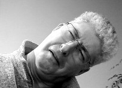

means "Why is this photo the wrong way round no matter how I turn the phone?"

### **Summary of application survey**

`TLDR: Depression diagnosis and pure research are the motives`

Most proposed business cases failed to withstand scrutiny. The commonest reasons to eliminate them were:

- competition with other ways of capturing emotion,
- emotion alone is insufficient data,
- ethics or social acceptability,
- practicalities other than AI implementation.

The most promising proposal is the diagnosis of depression for which we must only make a small investment to examine the single risk, namely, whether or not doctors would allow home-diagnosis *only* with the device. The near-misses are the game (which exists but whose purpose seems confused) and assistance for autistic people (in which the practicality of the hardware is in doubt).

In particular, the analysis of speech sounds seems to eclipse the facial expression approach whenever speech sounds are available. The gulf between the two is likely to widen as AI becomes more adept at extracting meaning from spoken words. Two people attempting to continue a video call after a failure of either the audio or the video would agree which of the two channels contains more information.

In the remaining applications where only facial images are available, they would usually be high quality videos from a frontal angle. This means that the FER2013 dataset presents irrelevant difficulties. A better dataset would be complete TV programs or films where emotional annotations apply to specific actors for specific time periods.

An absence of commercial motivation does not imply an absence of any motivation. Throughout history, seemingly pointless challenges have been attempted in the hope of spinning off commercial applications. PKI encryption would not have been possible without centuries of prior research about number theory before any application could have been foreseen. Ironically, the technique of extracting emotion from speech sounds (so frequently invoked as a killer above) is itself based on CNNs which originated as a way to analyse 2D images. Some attempts at facial emotion detection are using GNNs which have many unrelated applications. If a hard facial dataset drives people to perfect these technologies then it will have served its purpose. It's with this goal in mind that the rest of the present document should be justified.

## **Practical Experiments**

#### **About the dataset**

The data set consists of 3 folders, i.e., 'test', 'train', and 'validation'. Each of these folders has four subfolders:

**‘happy’**: Images of people who have happy facial expressions.  
**‘sad’**: Images of people with sad or upset facial expressions.  
**‘surprise’**: Images of people who have shocked or surprised facial expressions.  
**‘neutral’**: Images of people showing no prominent emotion in their facial expression at all.

#### **Note on coding style**

In the elective project I used a java-like style of OO in which many functions were bundled with data. This proved incovenient because the functions needed to be edited often, but the class instances only received the updates when the whole instance was recreated, necessitating frequent and avoidable discarding of data. Therefore, the style below uses classes to bundle data merely to enable dotted notation rather than the less convenient square brackets and quotation marks, but the functions operating on those instances are mostly global.

I found that I could perform experiments much faster on my own GPU than on colab, so some results are reported here done on my machine. There's inevitably some non-determinism when using a GPU because of the parallelism and the varying number of free GPU cores.

#### **Imports and GPU check**

```python
# Import everything
import os
import zipfile
import tensorflow as tf
import tensorflow.keras as ks
import tensorflow.keras.utils as ku
import matplotlib.pyplot as plt
import matplotlib.image as mpimg
import pandas as pd
import seaborn as sns
import numpy as np
from sklearn.metrics import classification_report, confusion_matrix
from tensorflow.keras.applications.vgg16 import VGG16
from keras.callbacks import ModelCheckpoint, EarlyStopping, ReduceLROnPlateau
import tensorflow.keras.applications as ap

# Check that we have a GPU:
import tensorflow as tf
print(tf.test.gpu_device_name())
```

#### **Data Exploration**

```python
# Mount google drive
from google.colab import drive
drive.mount('/mnt')

root = '/mnt/My Drive/MIT-AI/Faces/'
path_images = root + 'Facial_emotion_images'
path_zip = root + 'Facial_emotion_images.zip'

# Unpack the zip
if os.path.isdir(path_images):
  print("Images already extracted from zipfile")
else:
  print('Extracting images from zipfile')
  if os.path.isfile(path_zip):
    with zipfile.ZipFile(path_zip, 'r') as zip_ref:
      zip_ref.extractall(root)
  else:
    print('Zipfile not found at' + path_zip)
```

```
Mounted at /mnt
Images already extracted from zipfile
```

By examining the images with linux's `file` utility I determined that they are all 48x48 monochrome jpeg images.

#### **Visualizing our Classes**

```python
num_in_preview = 64

def show_some_faces(mood):
  plt.figure(figsize = (8,9))
  filenames = os.listdir(path_images+'/train/'+mood)[0:num_in_preview+64]
  for i in range(0,num_in_preview):
    ax = plt.subplot(num_in_preview//8, 8, i + 1)
    img = mpimg.imread(path_images+'/train/'+mood+'/'+filenames[i+64])
    imgplot = plt.imshow(img, cmap='gray')
    plt.axis("off")
  plt.show()
```

#### *All Classes*

This appears to be a subset of FER2013.

As already stated, all images are monochrome 48x48 jpegs.

There's a mixture of races and general lighting levels. It might therefore be worth normalising the brightness and its variance in each image.

There's a great variety of angles from which the faces are photographed.

Many images seem to have been gleaned from TV or film. This means that the people tend to be prettier than most of us, which in computational terms means more average. The general population has faces that vary in proportion more than this, which would make the problem harder.

Occlusion is fairly common, with hands, hair or sunglasses obscuring the face.

Several pictures show an expression in between two clear categories, in particular, between happy and surprised and between neutral and sad.

Some pictures even appear to be misclassified.

They've all been cropped using a Haar face detector or the like.

Often there are watermarks which are usually intended to prevent distribution.

#### *Happy*

Usually it's the smile that typifies this class. I expect good accuracy on images where the mouth is open and the teeth visible. When the mouth is closed it's debatable whether or not neutral would have been the better choice of class. The surprised category also tends to show open mouths so I'd espect some confusion there.

[figure not shown]

```python
show_some_faces('happy')
```

#### *Sad*

This category includes several distinct expressions. Some appear passively depressed while others are crying or look disgusted or fearful. I'd expect lots of confusion with the neutral category.

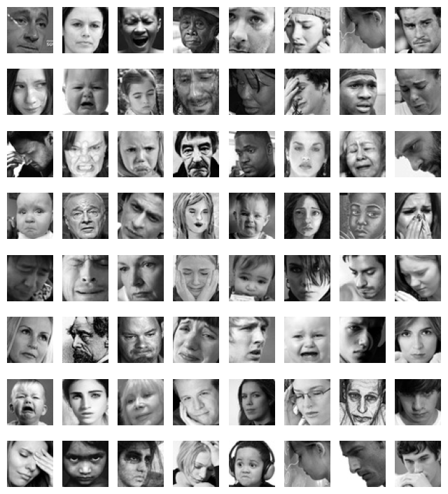

```python
show_some_faces('sad')
```

#### *Neutral*

Many of these look quite sad and some look happy.

[figure not shown]

```python
show_some_faces('neutral')
```

#### *Surprise*

There are some misclassifications here like the second from the right on the top row and the second from the left on the fifth row. Some clearly look happy or scared and one is corrupted.

[figure not shown]

```python
show_some_faces('surprise')
```

#### **Creating our Data Loaders**

I'll use `tf.data.Dataset` rather than `ImageDataGenerator` because the latter is deprecated and slow.

It's hard to imagine that loading the images in RGB mode would have any benefit because all three channels of a pixel would always have the same value. There would simply be three times as many weights from the input layer to the first calculated layer, but as long as all three channels had the same intensity, this would just be equivalent to one weight whose value was the sum (or average) of those three. Everything including the first calculated layer and downstream of there would be exactly the same. Nevertheless, the following code can load data in monochrome or RGB mode.

```python
# This returns a tf.data.Dataset object with batch size 32, shuffled, and categories corresponding to the directories.
# ImageDataGenerator is deprecated and much slower.

def load(dir, mode): # Returns a Dataset
  return ku.image_dataset_from_directory(
      path_images + '/' + dir,
      color_mode=mode,
      image_size=(48,48),
      label_mode='categorical'
      )

class D: # Encapsulate a three-section loaded dataset with a hint about the number of channels required in an input layer
  def __init__(s, mode, num_channels):
    s.train = load('train', mode)
    s.test  = load('test', mode)
    s.val   = load('validation', mode)
    s.ch = num_channels # This will be passed to model builders later

gray = D('grayscale', 1) # Load a D

class_names = gray.test.class_names # We want this in the correct order,
num_classes = len(class_names)  # so it's no good using os.listdir

print(class_names)
```

```
Found 15109 files belonging to 4 classes.
Found 128 files belonging to 4 classes.
Found 4977 files belonging to 4 classes.
['happy', 'neutral', 'sad', 'surprise']
```

#### **Checking Distribution of Classes**

```python
class_counts=[0]*num_classes
# We can calculate this from the dataset but it's slow
for i in range(0,num_classes):
  class_counts[i] = len(os.listdir(path_images+'/train/'+class_names[i]))
  print(class_names[i] + ':' + str(class_counts[i]))
```

```
happy:3976
neutral:3978
sad:3982
surprise:3173
```

The 'surprise' category is slightly under-represented and I expect that would mean that the weights in the trained network would be less influenced by that category. It's debatable whether this small imbalance would hurt very much, but the fix is very easy anyway. We supply the `class_weights` parameter to `Model.fit` with weights that are inversely proportional to the number of samples in the respective class.

```python
# Derive the map for the class_weights parameter
max_count = float(max(class_counts))
class_weights = { n: max_count/class_counts[n] for n in range(0, num_classes) }
print(class_weights)
```

```
{0: 1.0015090543259557, 1: 1.0010055304172951, 2: 1.0, 3: 1.2549637566971321}
```

#### **Utility code for running experiments**

Wanting to compare architectures fairly, I developed a common policy on hyperparameters and other details.

Early stopping failed due to choppiness in validation accuracies so instead I exponentially cool the learning rate from 0.002 to 0.0005 over 20 epochs.

On the transfer learning experiments I found no benefit in making the final classifier bigger than a single ReLU layer of 16 nodes followed by the softmax layer.

Since colab was preposterously slow I did some experiments on my own machine and entered the results in text blocks. In such cases it is obvious how to modify the code here to do the other experiment. Since my machine was a GPU which massively parallelises on a varying number of cores, there is some non-determinism in those experiments despite fixing random seeds.

```python
# I'm sick of endlessly waiting for training while developing...
epoch_divider = 1
# The accuracies claimed in the text boxes were obtained on my
# computer, not on colab. I'm making a last ditch attempt to
# run the whole notebook on colab overnight, which might succeed,
# but might give slightly different accuracies.

# Makes a model from a provided factory function,
# trains it and plots the learning curve
def learn(model_maker, d, * ,epochs=20, callbacks=None):
  ks.utils.set_random_seed(6296185)
  m = model_maker(d.ch) # The parameter gets used to make the input layer
  m.summary()
  eps = epochs // epoch_divider
  h = m.fit(d.train, epochs=eps,
            validation_data=d.val, # The test set is too small to give accurate results
            class_weight=class_weights,
            callbacks=callbacks) # I didn't use the callbacks in the end cos they unleashed chaos

  # On my own machine I now write h's accuracy and val_accuracy to a file
  #  which is under source control, as is the python code.
  # There's a makefile that runs the python and then commits both files.
  # In this way I keep a reliable record of experiments and results.

  graph = pd.DataFrame({
    'Epoch'        : range(1, eps+1),
    'accuracy'     : h.history['accuracy'],
    'val_accuracy' : h.history['val_accuracy']
  })
  sns.lineplot(x='Epoch', y='value', hue='variable', data=pd.melt(graph, ['Epoch']));
  plt.show()
  return m

# Expects a trained model and instance of D, tries classification
# on the validation portion of the D and shows the results.
def try_prediction(m, d):
  # This turned out to be a real drag using tf.data.Dataset
  # This solution unfortunately abandons lazy loading and puts everything in RAM.

  y_pred = []  # store predicted labels
  y_true = []  # store true labels

  # iterate over the dataset, batch by batch
  for image_batch, label_batch in d.val: # The test set is too small to give accurate accuracy measurements.
    y_true.append( np.array(list(map(lambda x: np.argmax(x), label_batch)))) # Un-one-hot-encoding and glueing numerous types of list together
    preds = m.predict(image_batch, verbose=0) # The important bit
    y_pred.append(np.argmax(preds, axis = - 1)) # More un-one-hotting

  y_pred= np.concatenate(y_pred) # And yet more list glueing
  y_true= np.concatenate(y_true)

  print("Classification report:")
  print(classification_report(y_true, y_pred)) # Compare with test Ys rescued from before one-hot encoding
  print("Confusion matrix:")
  c=confusion_matrix(y_true, y_pred) # Ditto
  print(c)
  sns.heatmap(c)
  plt.show()

# I tried some checkpoints but they just gave grief cos the learning curve was very choppy
# I'd rather keep the scientific control, and this seemed like an effective one-size-fits-all policy
# This exponentially reducing learning rate was introduced in response to the transfer learning experiments but adopted for everything
lr_schedule = ks.optimizers.schedules.ExponentialDecay( # Start at 0.002 and fall exponentially to 0.0005 over 20 epochs
  initial_learning_rate=2e-3,
  decay_steps=473, # one epoch
  decay_rate=0.933) # Tenth root of 0.5

def compile(m): # Stuff like this should be defined globally for the sake of scientific control in comparing models
  m.compile( # Compile the model with ...
    loss='categorical_crossentropy', # the loss equal to categorical_crossentropy,
    optimizer=ks.optimizers.Adam(learning_rate=lr_schedule), # optimizer doing Adam with learning_rate falling from 0.002 to 0.0005,
    metrics=['accuracy'] )
```

#### **Define the Base Neural Network**

```python
def addConvMaxpoolDropout(model, filters, kernel, pool, dropout):
    model.add(ks.layers.Conv2D(filters, (kernel,kernel), padding='same'))
    model.add(ks.layers.LeakyReLU(alpha=0.1))
    model.add(ks.layers.MaxPooling2D((pool, pool)))
    model.add(ks.layers.Dropout(dropout))

def cnn1(channels): # This channels parameter will be sucked out of the passed data set by learn()
    model = ks.Sequential()
    model.add(ks.layers.InputLayer((48,48,channels)))
    #model.add(ks.layers.RandomFlip("horizontal")), # This attempt at data augmentation brought no benefit.
    #model.add(ks.layers.RandomRotation(1)),        # If you put it here in the model you get a different variant on each epoch
    addConvMaxpoolDropout(model, 64, 2, 2, 0.2)     # (which is good) and it correctly does nothing during validation.
    addConvMaxpoolDropout(model, 32, 2, 2, 0.2)
    addConvMaxpoolDropout(model, 32, 2, 2, 0.2)
    model.add(ks.layers.Flatten())
    model.add(ks.layers.Dense(512, activation='relu'))
    model.add(ks.layers.Dropout(0.4))
    model.add(ks.layers.Dense(4, activation='softmax'))
    compile(model)
    return model
```

#### **Train and Evaluate the Base Model**

The first design in the low-code template showed training and validation accuracies around 68% after 20 epochs. I tried some forms of data augmentation but they degraded the accuracy, probably because there's no sign of overfitting at this stage. We can move directly to the larger model.

```
Model: "sequential"
_________________________________________________________________
 Layer (type)                Output Shape              Param #
=================================================================
 conv2d (Conv2D)             (None, 48, 48, 64)        320

 leaky_re_lu (LeakyReLU)     (None, 48, 48, 64)        0

 max_pooling2d (MaxPooling2  (None, 24, 24, 64)        0
 D)

 dropout (Dropout)           (None, 24, 24, 64)        0

 conv2d_1 (Conv2D)           (None, 24, 24, 32)        8224

 leaky_re_lu_1 (LeakyReLU)   (None, 24, 24, 32)        0

 max_pooling2d_1 (MaxPoolin  (None, 12, 12, 32)        0
 g2D)

 dropout_1 (Dropout)         (None, 12, 12, 32)        0

 conv2d_2 (Conv2D)           (None, 12, 12, 32)        4128

 leaky_re_lu_2 (LeakyReLU)   (None, 12, 12, 32)        0

 max_pooling2d_2 (MaxPoolin  (None, 6, 6, 32)          0
 g2D)

 dropout_2 (Dropout)         (None, 6, 6, 32)          0

 flatten (Flatten)           (None, 1152)              0

 dense (Dense)               (None, 512)               590336

 dropout_3 (Dropout)         (None, 512)               0

 dense_1 (Dense)             (None, 4)                 2052

=================================================================
Total params: 605060 (2.31 MB)
Trainable params: 605060 (2.31 MB)
Non-trainable params: 0 (0.00 Byte)
_________________________________________________________________
```

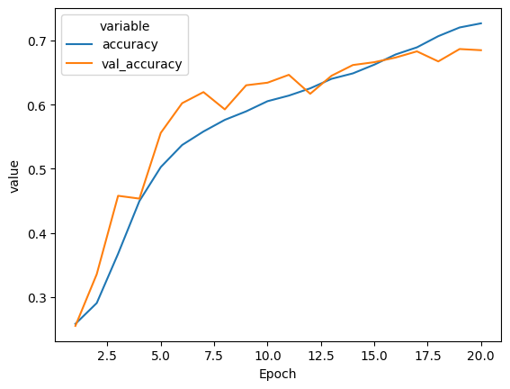

```python
m1=learn(cnn1, gray)
```

On my PC at 20 epochs: val. acc. = 0.69, tr. acc. = 0.73

```
Classification report:
              precision    recall  f1-score   support

           0       0.81      0.75      0.78      1825
           1       0.60      0.62      0.61      1216
           2       0.58      0.53      0.55      1139
           3       0.68      0.85      0.76       797

    accuracy                           0.68      4977
   macro avg       0.67      0.69      0.67      4977
weighted avg       0.68      0.68      0.68      4977

Confusion matrix:
[[1367  167  177  114]
 [ 132  750  237   97]
 [ 136  299  602  102]
 [  58   30   30  679]]
```

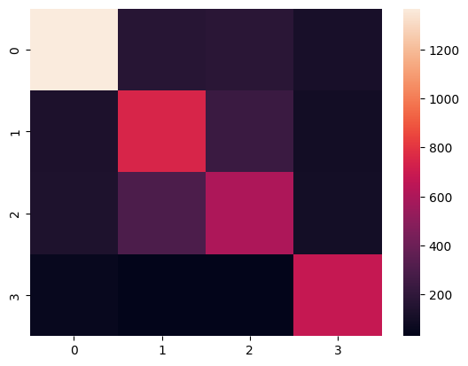

```python
try_prediction(m1, gray)
```

#### **Define the second Convolutional Neural Network**

- Try out a slightly larger architecture

```python
def addConvBatchnormMaxpoolDropout(model, filters, kernel, pool, dropout):
    model.add(ks.layers.Conv2D(filters, (kernel,kernel), padding='same', activation='relu'))
    model.add(ks.layers.BatchNormalization())
    model.add(ks.layers.LeakyReLU(alpha=0.1))
    model.add(ks.layers.MaxPooling2D((pool, pool)))
    model.add(ks.layers.Dropout(dropout))

def cnn2(channels):
    model = ks.Sequential()
    model.add(ks.layers.InputLayer((48,48,channels)))
    addConvBatchnormMaxpoolDropout(model, 256, 2, 2, 0.2)
    addConvBatchnormMaxpoolDropout(model, 128, 2, 2, 0.2)
    addConvBatchnormMaxpoolDropout(model, 64, 2, 2, 0.2)
    addConvBatchnormMaxpoolDropout(model, 32, 2, 2, 0.2)
    model.add(ks.layers.Flatten())
    model.add(ks.layers.Dense(512, activation='relu'))
    model.add(ks.layers.Dense(128, activation='relu'))
    model.add(ks.layers.Dense(4, activation='softmax'))
    compile(model)
    return model
```

#### **Train and Evaluate the Second Model**

This model stabilised around 77% training accuracy and 72% validation accuracy after 20 epochs, hence showing slight overfitting. I thus tried some augmentation but again it caused a deterioration.

```
Model: "sequential"
_________________________________________________________________
 Layer (type)                Output Shape              Param #
=================================================================
 conv2d (Conv2D)             (None, 48, 48, 256)       1280

 batch_normalization (Batch  (None, 48, 48, 256)       1024
 Normalization)

 leaky_re_lu (LeakyReLU)     (None, 48, 48, 256)       0

 max_pooling2d (MaxPooling2  (None, 24, 24, 256)       0
 D)

 dropout (Dropout)           (None, 24, 24, 256)       0

 conv2d_1 (Conv2D)           (None, 24, 24, 128)       131200

 batch_normalization_1 (Bat  (None, 24, 24, 128)       512
 chNormalization)

 leaky_re_lu_1 (LeakyReLU)   (None, 24, 24, 128)       0

 max_pooling2d_1 (MaxPoolin  (None, 12, 12, 128)       0
 g2D)

 dropout_1 (Dropout)         (None, 12, 12, 128)       0

 conv2d_2 (Conv2D)           (None, 12, 12, 64)        32832

 batch_normalization_2 (Bat  (None, 12, 12, 64)        256
 chNormalization)

 leaky_re_lu_2 (LeakyReLU)   (None, 12, 12, 64)        0

 max_pooling2d_2 (MaxPoolin  (None, 6, 6, 64)          0
 g2D)

 dropout_2 (Dropout)         (None, 6, 6, 64)          0

```

[output cut: 10 more lines]

```
 dropout_3 (Dropout)         (None, 3, 3, 32)          0

 flatten (Flatten)           (None, 288)               0

 dense (Dense)               (None, 512)               147968

 dense_1 (Dense)             (None, 128)               65664

 dense_2 (Dense)             (None, 4)                 516

=================================================================
Total params: 389604 (1.49 MB)
Trainable params: 388644 (1.48 MB)
Non-trainable params: 960 (3.75 KB)
_________________________________________________________________
```

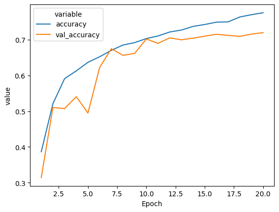

```python
m2 = learn(cnn2, gray)
```

On my machine at 20 epochs: val. acc. = 0.72, tr. acc = 0.77

```
Classification report:
              precision    recall  f1-score   support

           0       0.79      0.83      0.81      1825
           1       0.60      0.64      0.62      1216
           2       0.63      0.56      0.60      1139
           3       0.84      0.83      0.83       797

    accuracy                           0.72      4977
   macro avg       0.72      0.71      0.72      4977
weighted avg       0.72      0.72      0.72      4977

Confusion matrix:
[[1507  123  118   77]
 [ 198  775  222   21]
 [ 134  337  643   25]
 [  58   51   30  658]]
```

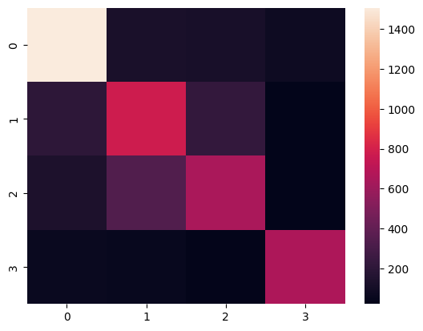

```python
try_prediction(m2, gray)
```

#### **Try the first model with RGB**

The grayscale model had 605060 weights while the colour one has 605572. The difference, 512, is explained as follows: we've added 2 channels to the input which projects onto 64 masks, each being a 2x2 kernel. So the extra number of weights we need is `2*64*2*2=512`.

I'm mystified as to why there'd be a difference between the performance of the two experiments. It seems to me that if the three channels are all feeding the same brightess to a neuron then whatever the loss calculated for that neuron might be, the three channels should share equal blame for it and undergo the same weight change, namely, a third of the change that a grayscale weight would have undergone. The per-channel weights started with different small random values but together they are equivalent to a single weight equal to the sum of the three weights. The loss at the neuron downstream of the RGB weights is a function of downstream stuff only which is exactly the same in the grayscale and RGB versions, so exotic activation functions like ReLU can't explain this.

[This section](https://en.wikipedia.org/wiki/Backpropagation#Finding_the_derivative_of_the_error) of wikipedia's page about backpropogation make it clear that (irrespective of the activation function) the change to a given weight is independent of the value of *that* weight.

By reducing the learning rate by a third, I made the validation accuracy of the RGB architecture approximate that of the monochrome architecture. But in that case the RGB architecture showed more overfitting. It would be interesting to play with the learning rate of only the first layer, but time didn't allow.

```python
rgb = D('rgb', 3) # Load the same data but convert to rgb,
# and tell the dataset to tell learn() to tell the model factory to put 3 channels in the input layer.
```

```
Found 15109 files belonging to 4 classes.
Found 128 files belonging to 4 classes.
Found 4977 files belonging to 4 classes.
```

```
Model: "sequential_1"
_________________________________________________________________
 Layer (type)                Output Shape              Param #
=================================================================
 conv2d_4 (Conv2D)           (None, 48, 48, 64)        832

 leaky_re_lu_4 (LeakyReLU)   (None, 48, 48, 64)        0

 max_pooling2d_4 (MaxPoolin  (None, 24, 24, 64)        0
 g2D)

 dropout_4 (Dropout)         (None, 24, 24, 64)        0

 conv2d_5 (Conv2D)           (None, 24, 24, 32)        8224

 leaky_re_lu_5 (LeakyReLU)   (None, 24, 24, 32)        0

 max_pooling2d_5 (MaxPoolin  (None, 12, 12, 32)        0
 g2D)

 dropout_5 (Dropout)         (None, 12, 12, 32)        0

 conv2d_6 (Conv2D)           (None, 12, 12, 32)        4128

 leaky_re_lu_6 (LeakyReLU)   (None, 12, 12, 32)        0

 max_pooling2d_6 (MaxPoolin  (None, 6, 6, 32)          0
 g2D)

 dropout_6 (Dropout)         (None, 6, 6, 32)          0

 flatten_1 (Flatten)         (None, 1152)              0

 dense_3 (Dense)             (None, 512)               590336

 dropout_7 (Dropout)         (None, 512)               0

 dense_4 (Dense)             (None, 4)                 2052

=================================================================
Total params: 605572 (2.31 MB)
Trainable params: 605572 (2.31 MB)
Non-trainable params: 0 (0.00 Byte)
_________________________________________________________________
```

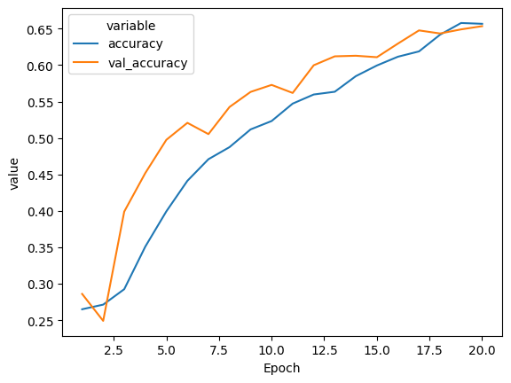

```python
m1rgb = learn(cnn1, rgb)
```

On my machine at 20 epochs: val. acc = 0.65, tr. acc. = 0.66

```
Classification report:
              precision    recall  f1-score   support

           0       0.81      0.70      0.75      1825
           1       0.56      0.60      0.58      1216
           2       0.53      0.50      0.52      1139
           3       0.66      0.84      0.74       797

    accuracy                           0.65      4977
   macro avg       0.64      0.66      0.65      4977
weighted avg       0.66      0.65      0.65      4977

Confusion matrix:
[[1277  216  192  140]
 [ 121  732  266   97]
 [ 142  313  570  114]
 [  31   54   39  673]]
```

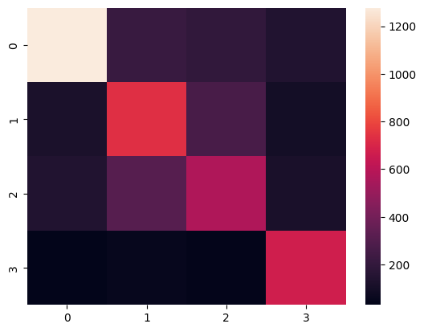

```python
try_prediction(m1rgb, rgb)
```

#### **Transfer Learning Architectures**

```python
# I already have the RGB data

# Same function, different style:
def convBatchnormMaxpoolDropout(filters, kernel, pool, dropout):
    def f(x):
        x = ks.layers.Conv2D(filters, (kernel,kernel), padding='same', activation='relu')(x)
        x = ks.layers.BatchNormalization()(x) # Add a BatchNormalization layer
        x = ks.layers.LeakyReLU(alpha=0.1)(x)
        x = ks.layers.MaxPooling2D((pool, pool))(x)
        x = ks.layers.Dropout(dropout)(x)
        return x
    return f

# This will add a classifier stage to a pre-trained model after the named layer
def add_classifier(cnn, layer_name, *, addconv=False):
  #cnn.summary()
  x = cnn.get_layer(layer_name).output
  cnn.trainable = False # So we will only train the added layers, not the pre-trained ones.
  if addconv: # For later
      x = convBatchnormMaxpoolDropout(128, 2, 2, 0.2)(x)
      x = convBatchnormMaxpoolDropout(64, 2, 2, 0.2)(x)
  x = ks.layers.Flatten()(x)
  x = ks.layers.Dense(16, activation = 'relu')(x)
  x = ks.layers.BatchNormalization()(x)
  x = ks.layers.Dropout(0.3)(x)
  pred = ks.layers.Dense(4, 'softmax')(x)
  model = ks.Model(cnn.input, pred)
  compile(model)
  return model
```

#### *VGG16 Model*

The design suggested in the low-code template overfitted horribly, with validation accuracy bouncing around 50% while training accuracy continued to the moon. ResNetV2 behaved similarly although not quite as bad. I therefore tried cutting out the first huge dense layer in the classifier, and then halving the sizes of the remaining two. This kept training accuracy within reasonable bounds but made no difference to validation accuracy. It later transpired that I could reduce the classifier to a single 16 node ReLU layer followed by the softmax layer without any disadvantages.

I noticed a lot of choppiness in the validation accuracy and introduced an exponentially reducing learning rate, now used throughout the report.

With those changes, the validation accuracy stabilised around 55%, potentially losing accuracy in later epochs due to overfitting.

VGG16 claims to be good at classifying everyday objects and animals and is therefore perhaps not a relevant place to start on the more subtle task of classifying facial expressions. But its early layers might be relevant. I therefore tried hanging the classifier off block3_pool (retaining the simplified classifier) and had more success, stabilising around 71% in validation after 20 epochs. Reaching for block2_pool or block4_pool gave results around 5-10% worse, so instead I tried restoring the full complexity of the classifier but the overfitting problem returned.

Hereafter I'm always using the very simple classifier and experimenting with the full pre-trained network and comparing it with the results when I tap off an intermediate layer. These runs in colab use the entire pre-trained network and I report the results of using only half of them in the text. In most cases training accuracy was 5-15% higher than validation accuracy (depending on the epoch), but it seems hard to cure this overfitting without simplifying the model so much as to reduce validation accuracy. Various data augmentation techniques failed to fix this so I suspect it's inevitable when the test set is too small for the number of weights required to represent the task.

```
Model: "model_4"
_________________________________________________________________
 Layer (type)                Output Shape              Param #
=================================================================
 input_5 (InputLayer)        [(None, 48, 48, 3)]       0

 block1_conv1 (Conv2D)       (None, 48, 48, 64)        1792

 block1_conv2 (Conv2D)       (None, 48, 48, 64)        36928

 block1_pool (MaxPooling2D)  (None, 24, 24, 64)        0

 block2_conv1 (Conv2D)       (None, 24, 24, 128)       73856

 block2_conv2 (Conv2D)       (None, 24, 24, 128)       147584

 block2_pool (MaxPooling2D)  (None, 12, 12, 128)       0

 block3_conv1 (Conv2D)       (None, 12, 12, 256)       295168

 block3_conv2 (Conv2D)       (None, 12, 12, 256)       590080

 block3_conv3 (Conv2D)       (None, 12, 12, 256)       590080

 block3_pool (MaxPooling2D)  (None, 6, 6, 256)         0

 block4_conv1 (Conv2D)       (None, 6, 6, 512)         1180160

 block4_conv2 (Conv2D)       (None, 6, 6, 512)         2359808

 block4_conv3 (Conv2D)       (None, 6, 6, 512)         2359808

 block4_pool (MaxPooling2D)  (None, 3, 3, 512)         0

 block5_conv1 (Conv2D)       (None, 3, 3, 512)         2359808

 block5_conv2 (Conv2D)       (None, 3, 3, 512)         2359808

 block5_conv3 (Conv2D)       (None, 3, 3, 512)         2359808

 block5_pool (MaxPooling2D)  (None, 1, 1, 512)         0

 flatten_4 (Flatten)         (None, 512)               0

 dense_8 (Dense)             (None, 16)                8208

 batch_normalization_4 (Bat  (None, 16)                64
 chNormalization)

 dropout_4 (Dropout)         (None, 16)                0

 dense_9 (Dense)             (None, 4)                 68

=================================================================
Total params: 14723028 (56.16 MB)
Trainable params: 8308 (32.45 KB)
Non-trainable params: 14714720 (56.13 MB)
_________________________________________________________________
```

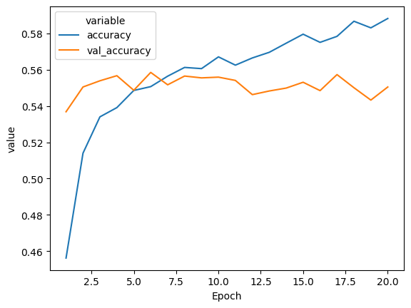

```python
def vgg1(channels):
  return add_classifier(VGG16(include_top = False, weights = 'imagenet', input_shape = (48, 48, channels)), 'block5_pool')

mVgg = learn(vgg1, rgb)
```

On my machine:

- using whole of VGG16: val. acc. = 0.57, tr. acc. = 0.61
- using only first half: val. acc. = 0.71, tr. acc. = 0.85

```
Classification report:
              precision    recall  f1-score   support

           0       0.70      0.54      0.61      1825
           1       0.46      0.52      0.49      1216
           2       0.48      0.50      0.49      1139
           3       0.55      0.70      0.61       797

    accuracy                           0.55      4977
   macro avg       0.55      0.56      0.55      4977
weighted avg       0.57      0.55      0.55      4977

Confusion matrix:
[[989 346 295 195]
 [177 629 254 156]
 [179 288 566 106]
 [ 70 103  68 556]]
```

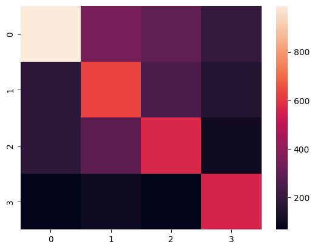

```python
try_prediction(mVgg, rgb)
```

#### *ResNet V2 Model*

ResNet is trained on the ImageNet dataset which similarly consists of everyday objects and animals. Attaching the simplified classifier described above to conv5_block3_add resulted in validation accuracy oscillating around 60% (56% on my machine) after 20 epochs. Attaching to conv3_block4_out improved it by 10%.

```
Model: "model_5"
__________________________________________________________________________________________________
 Layer (type)                Output Shape                 Param #   Connected to
==================================================================================================
 input_6 (InputLayer)        [(None, 48, 48, 3)]          0         []

 conv1_pad (ZeroPadding2D)   (None, 54, 54, 3)            0         ['input_6[0][0]']

 conv1_conv (Conv2D)         (None, 24, 24, 64)           9472      ['conv1_pad[0][0]']

 conv1_bn (BatchNormalizati  (None, 24, 24, 64)           256       ['conv1_conv[0][0]']
 on)

 conv1_relu (Activation)     (None, 24, 24, 64)           0         ['conv1_bn[0][0]']

 pool1_pad (ZeroPadding2D)   (None, 26, 26, 64)           0         ['conv1_relu[0][0]']

 pool1_pool (MaxPooling2D)   (None, 12, 12, 64)           0         ['pool1_pad[0][0]']

 conv2_block1_1_conv (Conv2  (None, 12, 12, 64)           4160      ['pool1_pool[0][0]']
 D)

 conv2_block1_1_bn (BatchNo  (None, 12, 12, 64)           256       ['conv2_block1_1_conv[0][0]']
 rmalization)

 conv2_block1_1_relu (Activ  (None, 12, 12, 64)           0         ['conv2_block1_1_bn[0][0]']
 ation)

 conv2_block1_2_conv (Conv2  (None, 12, 12, 64)           36928     ['conv2_block1_1_relu[0][0]']
 D)

 conv2_block1_2_bn (BatchNo  (None, 12, 12, 64)           256       ['conv2_block1_2_conv[0][0]']
 rmalization)

 conv2_block1_2_relu (Activ  (None, 12, 12, 64)           0         ['conv2_block1_2_bn[0][0]']
 ation)

 conv2_block1_0_conv (Conv2  (None, 12, 12, 256)          16640     ['pool1_pool[0][0]']
 D)

```

[output cut: 992 more lines]

```
 dense_10 (Dense)            (None, 16)                   131088    ['flatten_5[0][0]']

 batch_normalization_5 (Bat  (None, 16)                   64        ['dense_10[0][0]']
 chNormalization)

 dropout_5 (Dropout)         (None, 16)                   0         ['batch_normalization_5[0][0]'
                                                                    ]

 dense_11 (Dense)            (None, 4)                    68        ['dropout_5[0][0]']

==================================================================================================
Total params: 42789396 (163.23 MB)
Trainable params: 131188 (512.45 KB)
Non-trainable params: 42658208 (162.73 MB)
__________________________________________________________________________________________________
```

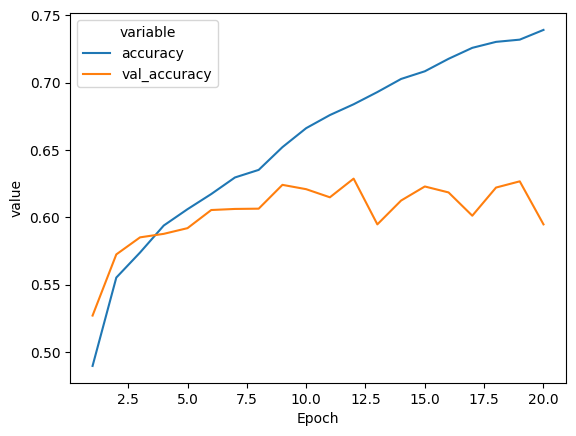

```python
def resnetv2(channels):
  return add_classifier(ap.ResNet101(include_top = False, weights = "imagenet", input_shape=(48,48,channels)), 'conv5_block3_add')

mRN = learn(resnetv2, rgb)
```

On my machine:

```
Classification report:
              precision    recall  f1-score   support

           0       0.73      0.64      0.68      1825
           1       0.43      0.74      0.54      1216
           2       0.62      0.29      0.40      1139
           3       0.73      0.71      0.72       797

    accuracy                           0.59      4977
   macro avg       0.63      0.59      0.59      4977
weighted avg       0.63      0.59      0.59      4977

Confusion matrix:
[[1167  467   98   93]
 [ 181  894   89   52]
 [ 194  550  334   61]
 [  64  154   14  565]]
```

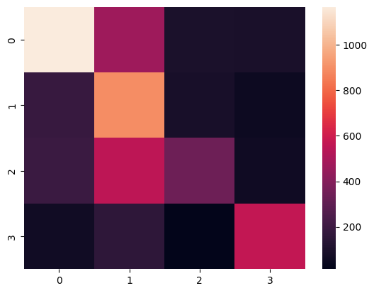

```python
try_prediction(mRN, rgb)
```

#### *EfficientNet Model*

This time the validation accuracy oscillated around 65%. When attaching the classifier to block3c_add the result was about 5% better.

```
Model: "model_6"
__________________________________________________________________________________________________
 Layer (type)                Output Shape                 Param #   Connected to
==================================================================================================
 input_7 (InputLayer)        [(None, 48, 48, 3)]          0         []

 rescaling_1 (Rescaling)     (None, 48, 48, 3)            0         ['input_7[0][0]']

 normalization_1 (Normaliza  (None, 48, 48, 3)            0         ['rescaling_1[0][0]']
 tion)

 stem_conv (Conv2D)          (None, 24, 24, 32)           864       ['normalization_1[0][0]']

 stem_bn (BatchNormalizatio  (None, 24, 24, 32)           128       ['stem_conv[0][0]']
 n)

 stem_activation (Activatio  (None, 24, 24, 32)           0         ['stem_bn[0][0]']
 n)

 block1a_project_conv (Conv  (None, 24, 24, 16)           4608      ['stem_activation[0][0]']
 2D)

 block1a_project_bn (BatchN  (None, 24, 24, 16)           64        ['block1a_project_conv[0][0]']
 ormalization)

 block1a_project_activation  (None, 24, 24, 16)           0         ['block1a_project_bn[0][0]']
  (Activation)

 block1b_project_conv (Conv  (None, 24, 24, 16)           2304      ['block1a_project_activation[0
 2D)                                                                ][0]']

 block1b_project_bn (BatchN  (None, 24, 24, 16)           64        ['block1b_project_conv[0][0]']
 ormalization)

 block1b_project_activation  (None, 24, 24, 16)           0         ['block1b_project_bn[0][0]']
  (Activation)

 block1b_drop (Dropout)      (None, 24, 24, 16)           0         ['block1b_project_activation[0
                                                                    ][0]']

```

[output cut: 699 more lines]

```
 dense_12 (Dense)            (None, 16)                   79888     ['flatten_6[0][0]']

 batch_normalization_6 (Bat  (None, 16)                   64        ['dense_12[0][0]']
 chNormalization)

 dropout_6 (Dropout)         (None, 16)                   0         ['batch_normalization_6[0][0]'
                                                                    ]

 dense_13 (Dense)            (None, 4)                    68        ['dropout_6[0][0]']

==================================================================================================
Total params: 4781626 (18.24 MB)
Trainable params: 79988 (312.45 KB)
Non-trainable params: 4701638 (17.94 MB)
__________________________________________________________________________________________________
```

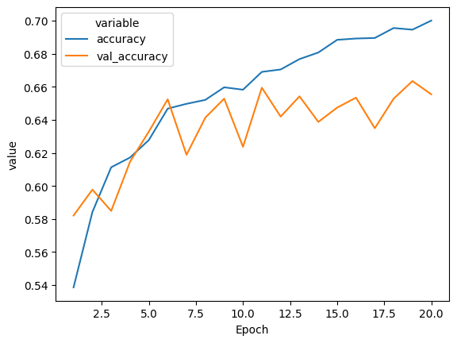

```python
def efnet(channels):
  return add_classifier(ap.EfficientNetV2B2(include_top=False,weights="imagenet", input_shape= (48, 48, channels)), 'block6e_expand_activation')

mEN = learn(efnet, rgb)
```

On my machine:

```
Classification report:
              precision    recall  f1-score   support

           0       0.71      0.80      0.75      1825
           1       0.60      0.48      0.53      1216
           2       0.58      0.54      0.56      1139
           3       0.70      0.76      0.72       797

    accuracy                           0.66      4977
   macro avg       0.64      0.64      0.64      4977
weighted avg       0.65      0.66      0.65      4977

Confusion matrix:
[[1461  109  170   85]
 [ 285  582  246  103]
 [ 237  210  617   75]
 [  89   72   34  602]]
```

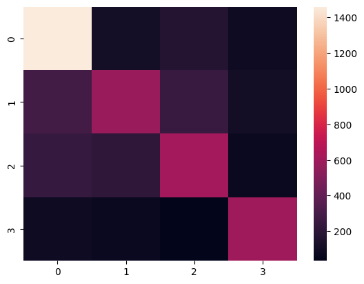

```python
try_prediction(mEN, rgb)
```

#### **Lessons from transfer learning**

It is likely that this attempt at transfer learning is suffering from the fact that these pre-trained networks might never before have seen a monochrome image. This is completely unrelated to my confusion earlier about a difference being observed in the opposite case that the network has never seen a colour image. There is no way of post-processing the trained network to think in monochrome because some of the filters in the first convolutional layer are likely to be playing explicitly colour-related roles.

For all three pre-trained networks, the early layers proved useful but not the later ones. This makes sense because the higher level features that these networks were trained on (like trees and cars) are irrelevant to facial expression recognition. The lower level features like lines, blobs and stripes would no longer be present in these later layers. By attaching the classifier to the last layer of the pre-trained network, we are asking the classifier to learn whether a face that's more tree-like than car-like looks happy or sad.

Therefore I tried adding a couple of trainable convolution blocks after the early portion of a pre-trained network. VGG16 is both cheap and effective compared to the other two. The result was an impressive 75% on validation.

```
Model: "model_7"
_________________________________________________________________
 Layer (type)                Output Shape              Param #
=================================================================
 input_8 (InputLayer)        [(None, 48, 48, 3)]       0

 block1_conv1 (Conv2D)       (None, 48, 48, 64)        1792

 block1_conv2 (Conv2D)       (None, 48, 48, 64)        36928

 block1_pool (MaxPooling2D)  (None, 24, 24, 64)        0

 block2_conv1 (Conv2D)       (None, 24, 24, 128)       73856

 block2_conv2 (Conv2D)       (None, 24, 24, 128)       147584

 block2_pool (MaxPooling2D)  (None, 12, 12, 128)       0

 block3_conv1 (Conv2D)       (None, 12, 12, 256)       295168

 block3_conv2 (Conv2D)       (None, 12, 12, 256)       590080

 block3_conv3 (Conv2D)       (None, 12, 12, 256)       590080

 block3_pool (MaxPooling2D)  (None, 6, 6, 256)         0

 conv2d (Conv2D)             (None, 6, 6, 128)         131200

 batch_normalization_7 (Bat  (None, 6, 6, 128)         512
 chNormalization)

 leaky_re_lu (LeakyReLU)     (None, 6, 6, 128)         0

 max_pooling2d (MaxPooling2  (None, 3, 3, 128)         0
 D)

 dropout_7 (Dropout)         (None, 3, 3, 128)         0

 conv2d_1 (Conv2D)           (None, 3, 3, 64)          32832

```

[output cut: 11 more lines]

```

 dense_14 (Dense)            (None, 16)                1040

 batch_normalization_9 (Bat  (None, 16)                64
 chNormalization)

 dropout_9 (Dropout)         (None, 16)                0

 dense_15 (Dense)            (None, 4)                 68

=================================================================
Total params: 1901460 (7.25 MB)
Trainable params: 165556 (646.70 KB)
Non-trainable params: 1735904 (6.62 MB)
_________________________________________________________________
```

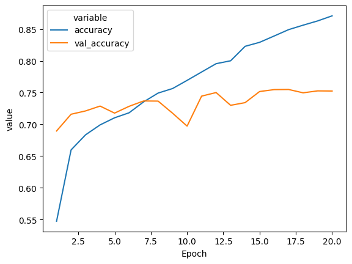

```python
def vgg1a(channels):
  return add_classifier(VGG16(include_top = False, weights = 'imagenet', input_shape = (48, 48, channels)), 'block3_pool',
                        addconv=True)

m = learn(vgg1a, rgb)
```

On my machine: val. acc. = 0.75, tr. acc. = 0.87

On my 4GB Nvidia Turing architecture GPU the above training proceeded at 6s per epoch and the validation on each epoch seemed instantaneous. I'm beginning to understand why data science people have a reputation for resisting the cloud.

```
Classification report:
              precision    recall  f1-score   support

           0       0.88      0.82      0.85      1825
           1       0.60      0.75      0.67      1216
           2       0.69      0.59      0.64      1139
           3       0.85      0.84      0.84       797

    accuracy                           0.75      4977
   macro avg       0.75      0.75      0.75      4977
weighted avg       0.76      0.75      0.75      4977

Confusion matrix:
[[1495  180   88   62]
 [  88  906  197   25]
 [  77  352  676   34]
 [  40   65   24  668]]
```

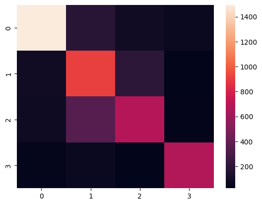

```python
try_prediction(m, rgb)
```

#### **Defining a Complex Neural Network Architecture**

This is the last of the architectures suggested in the low-code version. After 20 epochs this thing only scored 58% in validation against a training accuracy of 94%. This seems like the usual overfitting problem, which is hardly surprising in such a huge network. The overfitting is so pronounced that we can't deduce anything about the RGB vs. grayscale question. We have already achieved much better results.

```python
def deep(channels):
  # In this network, we plan to have 5 Convolutional Blocks
  i = ks.layers.Input((48,48,channels))
  # Add first Conv2D layer with 64 filters and a kernel size of 2. Use the 'same' padding and provide the input shape = (48, 48, 1). Use 'relu' activation.
  # Add your BatchNormalization layer followed by a LeakyRelU layer with Leaky ReLU parameter of 0.1
  # Add MaxPooling2D layer with pool size = 2.
  # Add a Dropout layer with a Dropout Ratio of 0.2. This completes the first Convolutional block.
  x = convBatchnormMaxpoolDropout(64, 2, 2, 0.2)(i)
  # Add a second Conv2D layer with 128 filters and a kernel size of 2. Use the 'same' padding and 'relu' activation.
  # Follow this up with a similar BatchNormalization, LeakyRelU, Maxpooling2D, and Dropout layer like above to complete your second Convolutional Block.
  x = convBatchnormMaxpoolDropout(128, 2, 2, 0.2)(i)
  # Add a third Conv2D layer with 512 filters and a kernel size of 2. Use the 'same' padding and 'relu' activation.
  # Once again, follow it up with a BatchNormalization, LeakyRelU, Maxpooling2D, and Dropout layer to complete your third Convolutional block.
  x = convBatchnormMaxpoolDropout(512, 2, 2, 0.2)(i)
  # Add a fourth block, with the Conv2D layer having 512 filters.
  x = convBatchnormMaxpoolDropout(512, 2, 2, 0.2)(i)
  # Add the fifth block, having 128 filters.
  x = convBatchnormMaxpoolDropout(128, 2, 2, 0.2)(i)
  # Then add your Flatten layer, followed by your Dense layers.
  x = ks.layers.Flatten()(x)
  # Add your first Dense layer with 256 neurons followed by a BatchNormalization layer, a 'relu' Activation, and a Dropout layer. This forms your first Fully Connected block
  x = ks.layers.Dense(256, activation = 'relu')(x)
  x = ks.layers.BatchNormalization()(x)
  x = ks.layers.Dropout(0.3)(x)
  # Add your second Dense layer with 512 neurons, again followed by a BatchNormalization layer, relu activation, and a Dropout layer.
  x = ks.layers.Dense(512, activation = 'relu')(x)
  x = ks.layers.BatchNormalization()(x)
  x = ks.layers.Dropout(0.3)(x)
  # Add your final Dense layer with 4 neurons.
  x = ks.layers.Dense(4, 'softmax')(x)
  # Compile your model with the optimizer of your choice.
  model = ks.Model(i, x)
  compile(model)
  return model
```

#### **Training and Evaluating the Complex Model**

```
Model: "model_8"
_________________________________________________________________
 Layer (type)                Output Shape              Param #
=================================================================
 input_9 (InputLayer)        [(None, 48, 48, 1)]       0

 conv2d_6 (Conv2D)           (None, 48, 48, 128)       640

 batch_normalization_14 (Ba  (None, 48, 48, 128)       512
 tchNormalization)

 leaky_re_lu_6 (LeakyReLU)   (None, 48, 48, 128)       0

 max_pooling2d_6 (MaxPoolin  (None, 24, 24, 128)       0
 g2D)

 dropout_14 (Dropout)        (None, 24, 24, 128)       0

 flatten_8 (Flatten)         (None, 73728)             0

 dense_16 (Dense)            (None, 256)               18874624

 batch_normalization_15 (Ba  (None, 256)               1024
 tchNormalization)

 dropout_15 (Dropout)        (None, 256)               0

 dense_17 (Dense)            (None, 512)               131584

 batch_normalization_16 (Ba  (None, 512)               2048
 tchNormalization)

 dropout_16 (Dropout)        (None, 512)               0

 dense_18 (Dense)            (None, 4)                 2052

=================================================================
Total params: 19012484 (72.53 MB)
Trainable params: 19010692 (72.52 MB)
Non-trainable params: 1792 (7.00 KB)
_________________________________________________________________
```

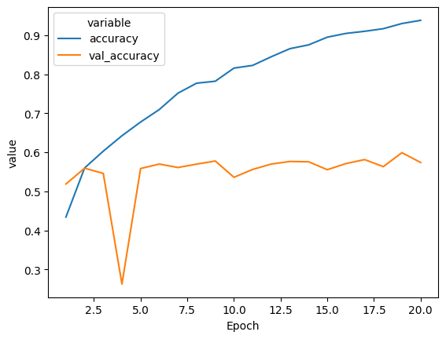

```python
mDeep = learn(deep, gray)
```

On my machine: val. acc. = 0.58, tr. acc. = 0.94

```
Classification report:
              precision    recall  f1-score   support

           0       0.78      0.54      0.64      1825
           1       0.51      0.50      0.51      1216
           2       0.44      0.53      0.48      1139
           3       0.58      0.81      0.67       797

    accuracy                           0.57      4977
   macro avg       0.58      0.60      0.58      4977
weighted avg       0.60      0.57      0.58      4977

Confusion matrix:
[[991 285 327 222]
 [119 614 360 123]
 [133 273 609 124]
 [ 34  43  78 642]]
```

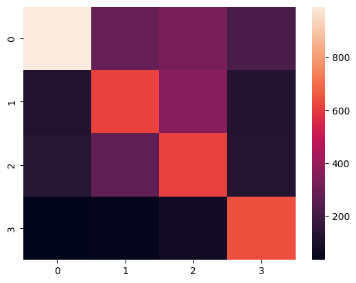

```python
try_prediction(mDeep, gray)
```

#### **Using Facial Landmark Detection**

The emotion detection problem has been attempted by first using a CNN to detect facial landmarks, somehow transforming them, and then using a dense classifier stage to learn emotional categories:

https://github.com/vishalsingh020997/Emotion-Recognition-using-Facial-Landmarks https://www.ncbi.nlm.nih.gov/pmc/articles/PMC9698760/

among others.

There's also a more complex approach [Ngoc, Quang Tran, Seunghyun Lee, and Byung Cheol Song. "Facial landmark-based emotion recognition via directed graph neural network." Electronics 9.5 (2020): 764] that feeds landmarks into a GNN with great results on video clips but they didn't try it on static images.

I felt the use of facial landmarks would be fruitful because of the large amount of human input provided during landmark labelling for these networks.

My chosen style of processing the landmarks for presentation to the network was to take pairwise distances, of which there are 2278 between the 68 landmarks reported by the dlib landmark detector:

`dlib.shape_predictor("shape_predictor_68_face_landmarks.dat")`

Taking pairwise distances is naturally invariant to tilting of the image, and after cropping with a face detector no other normalisation is required. The main distractor is the angle from which the face is viewed.

Usually a Haar classifier or the like would be used initially to locate faces in a larger image, but in the case of FER2013 the faces are already closely cropped. That leaves me with the options of either using a face detector or not. I tried both the opencv2 and dlib face detectors and found that they failed on about 25% of the images. When I ignored this fact and proceeded to the landmark detection phase anyway, those images on which detection had failed usually gave misplaced landmarks:

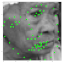

obviously failing classification. With these images included the validation accuracy was a dismal 50%. With them removed (and using the localisation from the face detector) it rose to a barely better 64%. Suspecting that the problem lay in the large number of pairwise distances between 68 points and the small training set, I pruned the landmarks down to the most informative 17, but there was no improvement so I abandonned the landmark-based approach.

#### *Code for the landmarks approach*

The code consists of three phases.

The first stage makes a copy of the entire directory tree of images but with each image file replaced with a file containing the pairwise distances between landmarks in a 1D numpy vector.

The second phase is a fairly mundane one in which each section (training, test and validation) is processed into two files called x.npy and y.npy containing all the features and labels of all the images in the respective section.

The third phase is training and validation using a simple neural network architecture.

This might seem like a clumsy process but the first two phases are much more time consuming than the training phase, and get revised much less often.

```python
# Make a tree of files containing landmark distances
#  corresponding to the tree of image files
# Do this once. It's very slow.
from os.path import join, isdir, isfile
from os import listdir, mkdir
import sys
import cv2
import dlib
import math
import numpy as np
import matplotlib.pyplot as plt
from imutils import face_utils

# Dlib freebies:
detector = dlib.get_frontal_face_detector() # Locate the face in the image
predictor = dlib.shape_predictor(join(root, "shape_predictor_68_face_landmarks.dat")) # Get the landmarks

# These are the most informative of the 68 landmarks:
useful_lms = [19, 21, 24, 26, 38, 41, 45, 48, 34, 51, 53, 62, 64, 68, 66, 57, 59] # counting from 1
num_lms = len(useful_lms)

# Throw away the useless ones:
def less_lms(all_lms):
    less = [0]*num_lms
    for a in range(0, num_lms):
        less[a] = all_lms[useful_lms[a]-1]
    return less

# Gonna output the euclidean distances
inp_len = num_lms * (num_lms-1) // 2 # Distance triangle for 68 points = 136
inp = [0] * inp_len # Avoid excess memory reallocations

# Helper for the below
def tree_(pre, pa):
    path = join(pre, pa)
    for p in listdir(path):
        pp = join(pa, p)
        if isdir(join(pre,pp)):
            yield pp
            yield from tree_(pre, pp)

# Recursively lists the subdirectories under `path` in a creatable order
# without including `path` in any of the results
def tree(path):
    for p in listdir(path):
        pp = join(path, p)
        if isdir(pp):
            yield p
            yield from tree_(path, p)

fro = path_images
to = root + 'Facial_emotion_landmarks'

if isdir(to):
  print(to + "already exists, exiting")
else:
  mkdir(to)
  for subdir in tree(fro): # All the directories under there at any depth
    image_dir = join(fro,subdir)   # E.g. Facial_emotion_images/train/happy
    landmark_dir = join(to,subdir) # E.g. Facial_emotion_landmarks/train/happy
    mkdir(landmark_dir)            # They're in a convenient order
    for im in listdir(image_dir):
      if isfile(join(image_dir, im)):
        im_path = join(image_dir, im)
        lm_path = join(landmark_dir, im)
        image  = cv2.imread(im_path)
        faces = detector(image, 1) # I think the 1 limits how many faces it looks for
        if len(faces) > 0: # Did we find an image
            lms = predictor(image, faces[0]) # Find all the landmarks
            lms = face_utils.shape_to_np(lms) # Not sure why we need this
            lms = less_lms(lms) # Keep only the useful ones
            a = 0 # Index in the output array
            # Calculate the distance triangle entries:
            for i in range(0,num_lms): # For all landmarks
                for j in range(i+1,num_lms): # For all landmarks later than that one
                    (xi,yi) = lms[i]
                    (xj,yj) = lms[j]
                    inp[a] = math.dist([xi,yi],[xj,yj])
                    a += 1
            np.save(lm_path, np.array(inp)) # One file for each image

print(f'Number of landmarks = {num_lms}')
print(f'Number of distances = {inp_len}')
```

```
Number of landmarks = 17
Number of distances = 136
```

```python
# Boil each of the training, test and validation sets down to an x.npy and y.npy file,
#  each such file containing data for all the images in the set.

def listsubdirs(path): # Gotta be careful cos I put the x.npy and y.npy files in there:
    return [d.name for d in os.scandir(path) if d.is_dir()]

for dataset in listsubdirs(to): # train, test, validation
  # Empty array of 136-vectors:
  x = np.empty((0,136))
  # Empty array of scalars:
  y = np.empty(0,)
  datasetdir = join(to, dataset)
  classes = listsubdirs(datasetdir)

  for c in range(0, len(classes)):
      cls = classes[c] # For each class
      classdir = join(datasetdir, cls)
      files = os.listdir(classdir)
      for file in files: # Get all the landmark-distance files
          d = np.load(join(classdir, file))
          x = np.vstack((x, d)) # Add the features to the big growing array
          y = np.append(y,c) # and the obvious class to its array

  np.save(join(datasetdir, 'x'), x) # The .npy extension is added
  np.save(join(datasetdir, 'y'), y) #  whether you like it or not.
  # They're sorted by y, so be sure to shuffle them later.
```

```python
# Third phase: training...

import numpy as np
import tensorflow as tf
import tensorflow.keras as ks

tra_path = join(to, 'train')
val_path = join(to, 'validation')

tra_x = np.load(join(tra_path,'x.npy'))
tra_y = tf.one_hot(np.load(join(tra_path, 'y.npy')), 4)
val_x = np.load(join(val_path,'x.npy'))
val_y = tf.one_hot(np.load(join(val_path, 'y.npy')), 4)

BATCH_SIZE = 32
ks.utils.set_random_seed(6296185)

tra_ds = tf.data.Dataset.from_tensor_slices((tra_x, tra_y)).shuffle(15000).batch(BATCH_SIZE)
val_ds = tf.data.Dataset.from_tensor_slices((val_x, val_y)).shuffle(15000).batch(BATCH_SIZE)

lr_schedule = ks.optimizers.schedules.ExponentialDecay(
  initial_learning_rate=2e-3,
  decay_steps=473, # one epoch
  decay_rate=0.966) # Tenth root of 0.5

def compile(m): # Stuff like this should be defined globally for the sake of scientific control in comparing models
  m.compile( # Compile the model with ...
    loss='categorical_crossentropy', # the loss equal to categorical_crossentropy,
    optimizer=ks.optimizers.Adam(learning_rate=lr_schedule), # optimizer doing Adam with learning_rate falling from 0.002 to 0.0005,
    metrics=['accuracy'] )

m = ks.Sequential([
    # Do what you like here, it never beats 65%, and that's after throwing away hard pictures.
    ks.layers.Dense(32, activation='relu', input_shape=(136,)),
    ks.layers.Dense(32, activation='relu'),
    ks.layers.Dense(4, activation='softmax')
    ])

compile(m)
h = m.fit(tra_ds, epochs=30, validation_data=val_ds)
# Still only 64% after 70 epochs, but at least it doesn't overfit...
# Epoch 70/70
# 332/332 [==============================] - 1s 4ms/step - loss: 0.9352 - accuracy: 0.6009 - val_loss: 0.8682 - val_accuracy: 0.6381
```

#### **Summary of technical section**

| Model | Val. acc. | Overfitting? |
| --- | --- | --- |
| Kaggle reference implementation verbatim | 65% | ? |
| Simple CNN | 68% | Y |
| Bigger CNN | 72% | Y |
| Simple CNN (RGB) | 65% | N |
| 1/2 VGG16 + dense | 71% | Y |
| 1/2 ResNet + dense | 66% | Y |
| 1/2 EffNet + dense | 70% | Y |
| Complex CNN | 58% | Y |
| Half of VGG16 + conv + dense | **75%** | Y |
| Landmark distances + dense (rejecting 25%) | 65% | N |

The best architectural approach is to use the first half of a pre-trained network followed by some trainable convolutional and dense layers yielding 75% accuracy. This technique compared favourably with shallow and deep architectures trained only on the provided dataset (most likely because that dataset is too small to train the early layers effectively) and with using the entire pre-trained network (because the problem at hand has no call for the high-level object recognition being performed by the later layers.) The approach of first obtaining pairwise distances between facial landmarks achieved a mediocre 65% on the images it didn't reject but without any overfitting.

## **Executive Summary**

#### *What are the most important findings from the analysis done in Milestone? Describe the final proposed model specifications?*

```
TLDR:
* Market research about depression diagnosis is recommended.
* Using the first half of a pre-trained network followed by
  trainable convolution and dense layers is the best architecture.
```

The most successful architecture I tried was "vgg1a". This consists of VGG16 up to the `block3_pool` layer, followed by two trainable convolutional blocks of 128 and 64 filters respectively, each block comprising the convolution with a 2x2 kernel, batch normalisation, 2x2 max pooling and 20% dropout. After said blocks comes the flattening and a single fully connected layer of 16 nodes, more batch normalisation and dropout and finally the 4 node softmax layer.

The rationale behind this architecture is that all the pre-trained networks are trained to classify everyday objects which is an entirely different task from classifying facial exressions, so we'd expect the final layers to be trained on irrelevant things like trees and cars and no longer contain detectors for lower-level features like circles and stripes that typify earlier layers and could be useful for our task.

There are many variations on this recipe that give similar validation accuracy (F1 score) of 75% whilst overfitting. I attempted several ways to combat the overfitting without hurting validation accuracy but none helped. Early stopping still presents itself but this would not improve validation accuracy so it seems unimportant. The advancing overfitting in the superfluous epochs is not accompanied by a loss of validation accuracy.

I imagine that 75% accuracy would be too low for the autistic assistance application because misclassifications could cause awkward misunderstandings. But it probably suffices for the depression diagnosis where the AI is just reducing variance in an established method, and for the gaming application where the technology is already aiming for the worst case scenario of causing maximum distress.

From the point of view of pure research, the finding that using only the early layers of a highly trained CNN led to the best outcome may be noteworthy. There might be similar effects in other types of network like R-CNNs or even LLMs.

All of these experiments strongly suggested that we do not have enough training data to train any network whose complexity sufficed to calculate facial expressions from such images. With more data, we might have enjoyed the same or better validation accuracies without the overfitting.

The dataset quality is also a limiting factor since many pictures seem ambiguous or misclassified, but that does not detract from the fact that overfitting was observed in models with the best validation accuracy.

## **Problem and Solution Summary**

#### *Provide the summary of the problem?*

The problem was summarised in the first section of this report: "Problem Definition."

#### *State the reasons for the proposed solution design?*

The reasons for the proposed solution design are that it delivered the best accuracy with low demand on system resources as explained in the executive summary. The applicability of the achieved accuracy in the surviving application scenario was discussed.

#### *How it would affect the problem/business?*

The effect of the technology on a range of application scenarios was discussed under "Problem Definition" as well as the executive summary.

## **Recommendations for implementation**

#### *What are some key recommendations to implement the solution?*

The most important recommendation is to use a pre-trained network but discard its later layers and attach trainable convolutional layers and a dense classifier to an intermediate layer. There are many possible variations of this architecture that would give similar results. Other findings include the fact that monochrome images should not be converted to three channels, that batch normalisation and dropout layers partially treat overfitting, and that the worst confusion occurs between the neutral and sad categories.

#### *What are the key actionables for stakeholders?*

I recommend considering only the depression diagnosis proposal. The business case is based on the hope of reducing costs and waiting times for diagnoses by removing the medic from the procedure and implementing a web-based system. The first action would be to research whether or not the medical profession considers that hope to be realistic. Given a positive response, clinical trials would be required. Risks thereafter would be quite mild and the profit margins considerable.

Outcomes for the gaming application could range from a short-lived gimmick to a social problem, and the help for autistic people could have adverse results in the light of the low accuracy and necessity to wear a camera.

All other suggestions were ruled out for various reasons.

I'd also recommend thinking beyond the narrow scope of extracting emotion from images like these. For instance:

- Estimating age from images would streamline supermarket checkouts where people are buying age-restricted items.
- Head and face movements can be an input device in numerous scenarios
- Police might be more interested in spotting suspicious behaviour on CCTVs than suspicious looks.
- High resolution colour videos from a narrower range of angles might be more representative of real-world conditions and easier to achieve good accuracy on.

#### *What is the expected benefit and/or costs (List the benefits of the solution. State some rational assumptions to put forward some numbers on costs/benefits for stakeholders)?*

Only the depression diagnosis proposal was admitted. The benefits as well as an order-of-magnitude financial projection has been provided in the relevant section of "Problem Definition".

#### *What are the potential risks or challenges of the proposed solution design?*

As mentioned, the main risk in the depression diagnosis project is the assumptioin that doctors would believe that the technology allows a cheaper method of diagnosis such as an automated video interview at home. This question could be answered relatively cheaply and a positive answer would result in a straightforward and lucrative business case. Thereafter, clinical trials would be required at a cost of around £5m but I cannot speculate on the chances of them succeeding.

#### *What further analysis needs to be done or what other associated problems need to be solved?*

The AI is in place but the whole system would need to gain expert approval and pass clinical trials.